# HW2

Group7:Alla Padma Poojitha, Pranavi Shakkari, Sri Harshita Bokka, Vamsikrishna Neppalli, Sai Vaila

11/10/2021

#Setting up the directory

#Call packages

```r
library(tidyverse)
library(Hmisc)
library(readxl)
library(psych)
```

```r
library(ggplot2)
library(PerformanceAnalytics)
library(car)
```

#Reading and viewing data

#Assigning dataframe name to the data

```r
data<-read_excel("C:/Users/13176/Downloads/Group7_FoodData_Infection.xlsx")
```

#viewing the top5 and bottom5 rows

```r
head(data)
```

```
## # A tibble: 6 x 12
##    Year Month State     `Genus Species` `Serotype or Genotype` `Etiology Status`
##   <dbl> <dbl> <chr>     <chr>           <chr>                  <chr>
## 1  2009     1 Minnesota Norovirus       <NA>                   Suspected
## 2  2009     1 Minnesota Norovirus       <NA>                   Confirmed
## 3  2009     1 Minnesota Norovirus       <NA>                   Suspected
## 4  2009     1 Minnesota Norovirus       <NA>                   Confirmed
## 5  2009     1 Minnesota Norovirus       <NA>                   Confirmed
## 6  2009     1 Minnesota Norovirus       <NA>                   Confirmed
## # ... with 6 more variables: Location of Preparation <chr>, Illnesses <dbl>,
## #   Hospitalizations <dbl>, Deaths <dbl>, Food Vehicle <chr>,
## #   Contaminated Ingredient <chr>
```

```r
tail(data)
```

```
## # A tibble: 6 x 12
##    Year Month State   `Genus Species`         `Serotype or Gen~ `Etiology Statu~
##   <dbl> <dbl> <chr>   <chr>                   <chr>             <chr>
## 1  2015    10 Florida <NA>                    <NA>              <NA>
## 2  2014    12 Idaho   Cryptosporidium         <NA>              Confirmed
## 3  2015     3 Idaho   Campylobacter           <NA>              Confirmed
## 4  2015     9 Idaho   Campylobacter jejuni; ~ O157:H7           Confirmed; Conf~
## 5  2015    11 Idaho   Campylobacter           <NA>              Confirmed
## 6  2015    12 Utah    Salmonella enterica     Virchow           Confirmed
## # ... with 6 more variables: Location of Preparation <chr>, Illnesses <dbl>,
## #   Hospitalizations <dbl>, Deaths <dbl>, Food Vehicle <chr>,
## #   Contaminated Ingredient <chr>
```

#Checking the size of the data

```r
dim(data)
```

```
## [1] 19119    12
```

#Finding the data types in data

```r
sapply(data,class)
```

```
##                    Year                   Month                   State
##               "numeric"               "numeric"             "character"
##           Genus Species    Serotype or Genotype         Etiology Status
##             "character"             "character"             "character"
## Location of Preparation               Illnesses        Hospitalizations
##             "character"               "numeric"               "numeric"
##                  Deaths            Food Vehicle Contaminated Ingredient
##               "numeric"             "character"             "character"
```

#Duplicating the dataframe

```r
new_data<-data
```

#omitting the NA vlues

```r
new_data<- new_data %>%
  na.omit()
```

#Renaming the columns ‘Genus Species’, ’ Etiology Status’, Location of Preparation

```r
new_data<-new_data %>%
  rename('gspecies' = 'Genus Species', 'etiostatus' = 'Etiology Status', 'PrepLocation' = 'Location of Preparation')
```

#removing the values after delimiter in column etiostatus

```r
new_data<-new_data %>% separate(etiostatus,
                                c("etiostatus"), extra='drop')
```

#Selecting the required columns and filtering the required data

```r
df <- new_data %>%
  select(Year, gspecies, Illnesses, Hospitalizations) %>%
  filter(Year ==2006|Year==2008|Year==2010)
```

#Converting coulumn gspecies to numerical format

```r
df$gspecies_num<-as.numeric(factor(as.matrix(df$gspecies)))
```

#Correlation Analysis

```r
cor_data1 <- df %>%
  select(Year, gspecies_num, Illnesses, Hospitalizations)
```

```r
cor(cor_data1)
```

```
##                          Year gspecies_num  Illnesses Hospitalizations
## Year              1.000000000  0.008102721 -0.0543775      -0.06756031
## gspecies_num      0.008102721  1.000000000  0.1085914      -0.15377320
## Illnesses        -0.054377502  0.108591443  1.0000000       0.66335863
## Hospitalizations -0.067560306 -0.153773200  0.6633586       1.00000000
```

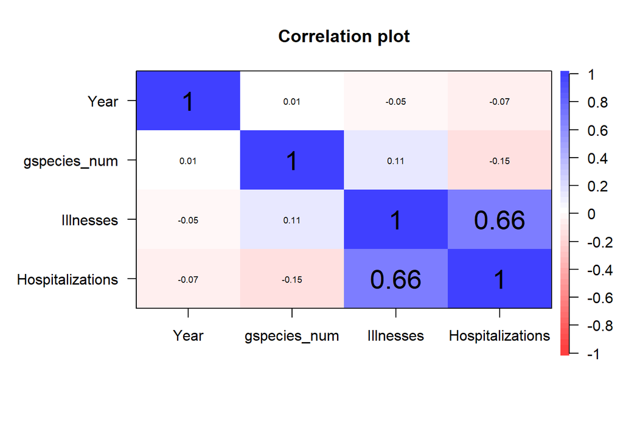

```r
corPlot(cor_data1, cex = 1.2)
```

#(i) Identify dependent and independent variables #INependent Variables - Genus Species and Year #dependent Variables - Illnesses and Hospitalizations

#(ii) Design Hypothesis #Null Hypothesis: Genus species affect the number of illnesses and hospitalizations #Alternative Hypothesis: genus will not affect the number of illnesses and hospitalizations

```r
df3 <- df%>%
  select('gspecies', 'Illnesses','Hospitalizations')
df3<-unique(df3)
```

#(iii) central theorem tendency for the groups.

```r
describe(df3)
```

```
##                  vars  n  mean    sd median trimmed   mad min max range  skew
## gspecies*           1 62  4.76  2.08    6.0    5.04  0.00   1   7     6 -1.13
## Illnesses           2 62 35.35 77.02   17.5   22.18 17.05   2 594   592  6.22
## Hospitalizations    3 62  4.63  6.15    2.0    3.36  2.97   0  31    31  2.12
##                  kurtosis   se
## gspecies*           -0.59 0.26
## Illnesses           41.79 9.78
## Hospitalizations     4.87 0.78
```

# (iv) Box plots for all the variables

```r
dev.off()
```

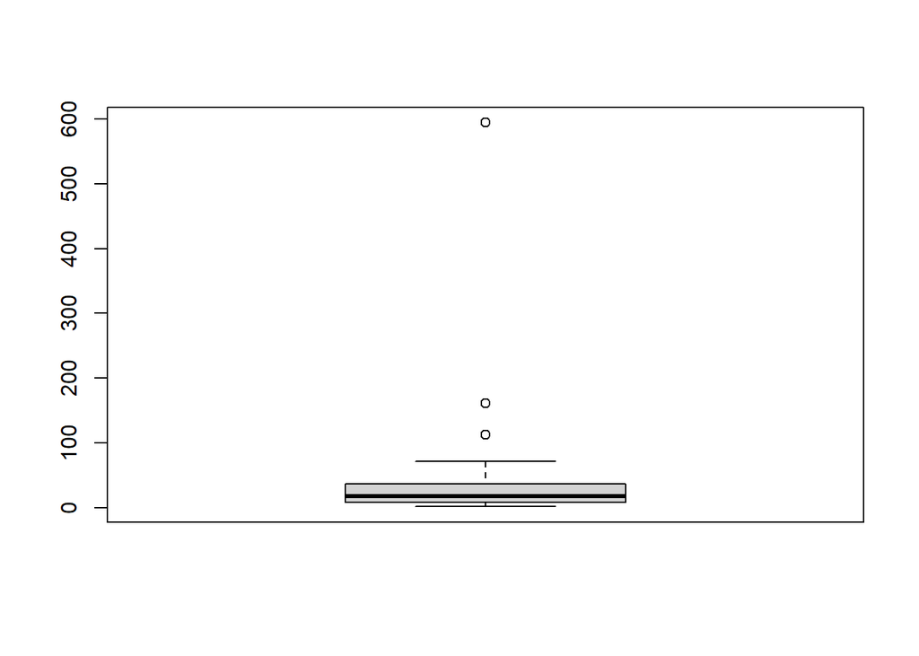

```r
boxplot(df3$Illnesses)
```

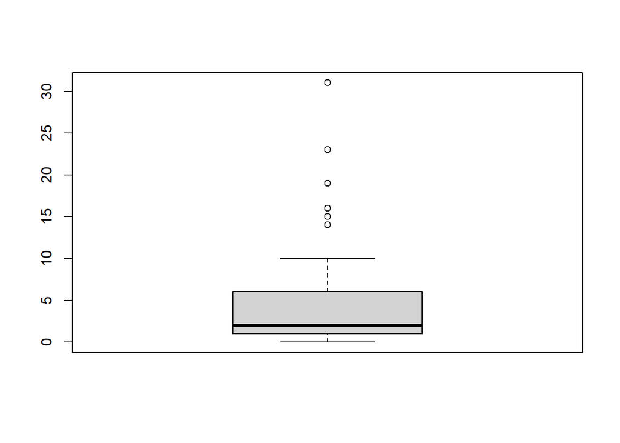

```r
boxplot(df3$Hospitalizations)
```

#removing the outliers

```r
x_out_rm <- df3$Illnesses[!df3$Illnesses %in% boxplot.stats(df3$Illnesses)$out]
length(df3$Illnesses) - length(x_out_rm)
```

```
## [1] 3
```

```r
x_out_rm <- df3$Hospitalizations[!df3$Illnesses %in% boxplot.stats(df3$Hospitalizations)$out]
length(df3$Hospitalizations) - length(x_out_rm)
```

```
## [1] 7
```

# (v). Based on the (i) and (ii) evaluate the outliers and extract for each feature 95% confidence interval data. Use this confidence interval data for further analysis.

```r
library(Rmisc)
CI(df3$Illnesses, ci=0.95)
```

```
##    upper     mean    lower
## 54.91375 35.35484 15.79593
```

```r
CI(df3$Hospitalizations, ci=0.95)
```

```
##    upper     mean    lower
## 6.191278 4.629032 3.066786
```

# (vi) Normality assumptions

#Hypothesis: #H0: : The data is normally distributed #H1: : The data is not normally distributed

```r
shapiro.test(df$gspecies_num)
```

```
##
##  Shapiro-Wilk normality test
##
## data:  df$gspecies_num
## W = 0.61246, p-value = 1.002e-11
```

```r
shapiro.test(df$Illnesses)
```

```
##
##  Shapiro-Wilk normality test
##
## data:  df$Illnesses
## W = 0.33535, p-value = 1.733e-15
```

```r
shapiro.test(df$Hospitalizations)
```

```
##
##  Shapiro-Wilk normality test
##
## data:  df$Hospitalizations
## W = 0.72164, p-value = 1.05e-09
```

# (vii). Perform the Homogeneity of Variance assumptions as taught in the class

```r
car::leveneTest(Illnesses~gspecies,data=df)
```

```
## Levene's Test for Homogeneity of Variance (center = median)
##       Df F value Pr(>F)
## group  6  0.2263 0.9666
##       57
```

```r
car::leveneTest(Hospitalizations~gspecies,data=df)
```

```
## Levene's Test for Homogeneity of Variance (center = median)
##       Df F value Pr(>F)
## group  6  0.4892 0.8137
##       57
```

```r
results1=aov(Hospitalizations ~ as.factor(gspecies_num)
             , data = df)
results2=aov(Hospitalizations ~ as.factor(gspecies_num)
             , data = df)
summary(results1)
```

```
##                         Df Sum Sq Mean Sq F value Pr(>F)
## as.factor(gspecies_num)  6  198.5   33.09   0.882  0.514
## Residuals               57 2137.4   37.50
```

```r
summary(results2)
```

```
##                         Df Sum Sq Mean Sq F value Pr(>F)
## as.factor(gspecies_num)  6  198.5   33.09   0.882  0.514
## Residuals               57 2137.4   37.50
```

# Post-Hoc Test

```r
TukeyHSD(results1, conf.level=0.95)
```

```
##   Tukey multiple comparisons of means
##     95% family-wise confidence level
##
## Fit: aov(formula = Hospitalizations ~ as.factor(gspecies_num), data = df)
##
## $`as.factor(gspecies_num)`
##              diff        lwr       upr     p adj
## 2-1 -5.000000e+00 -24.420595 14.420595 0.9853638
## 3-1 -5.000000e+00 -24.420595 14.420595 0.9853638
## 4-1 -7.000000e+00 -26.420595 12.420595 0.9250857
## 5-1 -6.750000e+00 -17.450227  3.950227 0.4710114
## 6-1 -2.534884e+00  -8.458110  3.388342 0.8454855
## 7-1 -6.000000e+00 -25.420595 13.420595 0.9634844
## 3-2  6.217249e-15 -26.465810 26.465810 1.0000000
## 4-2 -2.000000e+00 -28.465810 24.465810 0.9999862
## 5-2 -1.750000e+00 -22.673060 19.173060 0.9999748
## 6-2  2.465116e+00 -16.465393 21.395626 0.9996642
## 7-2 -1.000000e+00 -27.465810 25.465810 0.9999998
## 4-3 -2.000000e+00 -28.465810 24.465810 0.9999862
## 5-3 -1.750000e+00 -22.673060 19.173060 0.9999748
## 6-3  2.465116e+00 -16.465393 21.395626 0.9996642
## 7-3 -1.000000e+00 -27.465810 25.465810 0.9999998
## 5-4  2.500000e-01 -20.673060 21.173060 1.0000000
## 6-4  4.465116e+00 -14.465393 23.395626 0.9907482
## 7-4  1.000000e+00 -25.465810 27.465810 0.9999998
## 6-5  4.215116e+00  -5.567497 13.997730 0.8412967
## 7-5  7.500000e-01 -20.173060 21.673060 0.9999998
## 7-6 -3.465116e+00 -22.395626 15.465393 0.9976733
```

```r
TukeyHSD(results2, conf.level=0.95)
```

```
##   Tukey multiple comparisons of means
##     95% family-wise confidence level
##
## Fit: aov(formula = Hospitalizations ~ as.factor(gspecies_num), data = df)
##
## $`as.factor(gspecies_num)`
##              diff        lwr       upr     p adj
## 2-1 -5.000000e+00 -24.420595 14.420595 0.9853638
## 3-1 -5.000000e+00 -24.420595 14.420595 0.9853638
## 4-1 -7.000000e+00 -26.420595 12.420595 0.9250857
## 5-1 -6.750000e+00 -17.450227  3.950227 0.4710114
## 6-1 -2.534884e+00  -8.458110  3.388342 0.8454855
## 7-1 -6.000000e+00 -25.420595 13.420595 0.9634844
## 3-2  6.217249e-15 -26.465810 26.465810 1.0000000
## 4-2 -2.000000e+00 -28.465810 24.465810 0.9999862
## 5-2 -1.750000e+00 -22.673060 19.173060 0.9999748
## 6-2  2.465116e+00 -16.465393 21.395626 0.9996642
## 7-2 -1.000000e+00 -27.465810 25.465810 0.9999998
## 4-3 -2.000000e+00 -28.465810 24.465810 0.9999862
## 5-3 -1.750000e+00 -22.673060 19.173060 0.9999748
## 6-3  2.465116e+00 -16.465393 21.395626 0.9996642
## 7-3 -1.000000e+00 -27.465810 25.465810 0.9999998
## 5-4  2.500000e-01 -20.673060 21.173060 1.0000000
## 6-4  4.465116e+00 -14.465393 23.395626 0.9907482
## 7-4  1.000000e+00 -25.465810 27.465810 0.9999998
## 6-5  4.215116e+00  -5.567497 13.997730 0.8412967
## 7-5  7.500000e-01 -20.173060 21.673060 0.9999998
## 7-6 -3.465116e+00 -22.395626 15.465393 0.9976733
```

#Mapping states into regions

```r
xref <- c('Alaska'='west','Arizona'='west', 'California'='west', 'Hawaii'='west', 'Idaho'='west', 'Montana'='west', 'Nevada'='west', 'New Mexico'='west', 'Oregon'='west', 'Utah'='west', 'Washington'='west', 'Wyoming'='west', 'Illinois'='west', 'Indiana'='west', 'Iowa'='west', 'Kansas'='west', 'Michigan'='west','Minnesota'='west', 'Missouri'='west', 'Nebraska'='west', 'North Dakota'='west', 'Ohio'='west', 'South Dakota'='west','Wisconsin'='west','Colorado'='west',
          'Alabama'='east', 'Arkansas'='east', 'Florida'='east', 'Georgia'='east', 'Kentucky'='east', 'Louisiana'='east', 'Maryland'='east', 'Mississippi'='east', 'North Carolina' ='east', 'South Carolina'='east', 'Tennessee' ='east', 'Virginia'='east','West Virginia' ='east','Texas'='east','Oklahoma'='east','Pennsylvania'='east','Delaware'='east','New Jersey'='east','Connecticut'='east','New York'='east','Rhode Island'='east','New Hampshire'='east','Maine'='east','Massachusetts'='east','Vermont'='east')
```

#selecting and filtering the required variables

```r
df4 <- new_data %>%
  select(State, etiostatus, PrepLocation, Illnesses)%>%
  filter(!grepl('Multistate', State),grepl('Restaurant', PrepLocation),grepl('Confirmed',etiostatus))
```

#Assigning States to corresponding regions

```r
df4$region <- ifelse(is.na(xref[df4$State]), '*', xref[df4$State])

df4$region
```

```
##         Oregon       Virginia   Pennsylvania       New York         Oregon
##         "west"         "east"         "east"         "east"         "west"
##         Oregon     California   Pennsylvania     California     California
##         "west"         "west"         "east"         "west"         "west"
##       Colorado         Alaska       Colorado       Michigan        Georgia
##         "west"         "west"         "west"         "west"         "east"
##       Michigan       Illinois       New York      Minnesota       Maryland
##         "west"         "west"         "east"         "west"         "east"
##       Michigan           Ohio      Minnesota       Maryland      Minnesota
##         "west"         "west"         "west"         "east"         "west"
##     California   Pennsylvania        Florida           Ohio       Michigan
##         "west"         "east"         "east"         "west"         "west"
##     California       Maryland  Massachusetts  Massachusetts      Tennessee
##         "west"         "east"         "east"         "east"         "east"
##       Virginia        Florida       Nebraska      Tennessee South Carolina
##         "east"         "east"         "west"         "east"         "east"
## South Carolina      Tennessee        Arizona           Ohio       Kentucky
##         "east"         "east"         "west"         "west"         "east"
##       Michigan       Colorado     California    Connecticut       Virginia
##         "west"         "west"         "west"         "east"         "east"
##         Alaska           Utah    Connecticut      Minnesota      Minnesota
##         "west"         "west"         "east"         "west"         "west"
##       Kentucky  Massachusetts    Mississippi       Illinois        Florida
##         "east"         "east"         "east"         "west"         "east"
##      Minnesota       Maryland  West Virginia       Virginia          Texas
##         "west"         "east"         "east"         "east"         "east"
##           Ohio       Nebraska       Maryland  Massachusetts        Georgia
##         "west"         "west"         "east"         "east"         "east"
##     California     California     California     California     California
##         "west"         "west"         "west"         "west"         "west"
##        Arizona     Washington      Tennessee   Pennsylvania       Oklahoma
##         "west"         "west"         "east"         "east"         "east"
##           Ohio           Ohio       Michigan       Michigan          Maine
##         "west"         "west"         "west"         "west"         "east"
##          Maine       Maryland       Maryland        Georgia     California
##         "east"         "east"         "east"         "east"         "west"
##     California       Arkansas       Arkansas        Alabama       Maryland
##         "west"         "east"         "east"         "east"         "east"
##      Minnesota      Minnesota     California     California     Washington
##         "west"         "west"         "west"         "west"         "west"
```

[output cut: 17 more lines]

```
##         "east"         "east"         "west"         "east"         "east"
##       New York       Virginia     California     California       New York
##         "east"         "east"         "west"         "west"         "east"
##       New York        Florida       Colorado     California     California
##         "east"         "east"         "west"         "west"         "west"
##     California      Wisconsin      Wisconsin       New York  Massachusetts
##         "west"         "west"         "west"         "east"         "east"
##       Missouri         Kansas       Michigan         Oregon        Florida
##         "west"         "west"         "west"         "west"         "east"
##         Hawaii North Carolina         Hawaii       Virginia           Ohio
##         "west"         "east"         "west"         "east"         "west"
##         Hawaii      Tennessee        Florida       Maryland    Connecticut
##         "west"         "east"         "east"         "east"         "east"
##     California
##         "west"
```